# Salamander Counts and Covariates

## Salamander Counts and Covariates: A Study

### Rashmi Ravichandran

```python
#Importing Pandas and Dataset from local computer

#Data contains 148 rows and 13 columns

import pandas as pd
import matplotlib.pyplot as plt
import seaborn as sns

import warnings
warnings.filterwarnings('ignore')

data = pd.read_csv("C:/Users/s1924516/OneDrive - 7-Eleven, Inc/Documents/Data/Barton_Spring_Salamander_Counts_and_Covariates.csv", parse_dates = [1])
data.head()
```

|  | ID | Year-Month | Parthenia_juvenile | Parthenia_subadult | Parthenia_adult | Eliza_juvenile | Eliza_subadult | Eliza_adult | Discharge_BS | Parthenia_sedcov | Parthenia_filalgae | Eliza_sedcov | Eliza_filalgae |
| --- | --- | --- | --- | --- | --- | --- | --- | --- | --- | --- | --- | --- | --- |
| 0 | 1 | 2002-10-01 | NaN | NaN | NaN | NaN | NaN | NaN | 85.8 | NaN | NaN | NaN | NaN |
| 1 | 2 | 2002-11-01 | NaN | NaN | NaN | NaN | NaN | NaN | 98.2 | NaN | NaN | NaN | NaN |
| 2 | 3 | 2002-12-01 | NaN | NaN | NaN | NaN | NaN | NaN | 106.5 | NaN | NaN | NaN | NaN |
| 3 | 4 | 2003-01-01 | NaN | NaN | NaN | NaN | NaN | NaN | 108.8 | NaN | NaN | NaN | NaN |
| 4 | 5 | 2003-02-01 | NaN | NaN | NaN | NaN | NaN | NaN | 113.8 | NaN | NaN | NaN | NaN |

```python
#Observing Several NA Entries, counting the NAs for each column

data.isnull().sum(axis = 0)
```

```
ID                     0
Year-Month             0
Parthenia_juvenile    68
Parthenia_subadult    68
Parthenia_adult       68
Eliza_juvenile        48
Eliza_subadult        48
Eliza_adult           48
Discharge_BS           0
Parthenia_sedcov      70
Parthenia_filalgae    70
Eliza_sedcov          46
Eliza_filalgae        46
dtype: int64
```

```python
#Learing about the different datatypes
data.info()
data['Year'] = pd.DatetimeIndex(data['Year-Month']).year
data['Month'] = pd.DatetimeIndex(data['Year-Month']).month

#Data now has 148 rows and 15 columns
```

```
<class 'pandas.core.frame.DataFrame'>
RangeIndex: 148 entries, 0 to 147
Data columns (total 13 columns):
ID                    148 non-null int64
Year-Month            148 non-null datetime64[ns]
Parthenia_juvenile    80 non-null float64
Parthenia_subadult    80 non-null float64
Parthenia_adult       80 non-null float64
Eliza_juvenile        100 non-null float64
Eliza_subadult        100 non-null float64
Eliza_adult           100 non-null float64
Discharge_BS          148 non-null float64
Parthenia_sedcov      78 non-null float64
Parthenia_filalgae    78 non-null float64
Eliza_sedcov          102 non-null float64
Eliza_filalgae        102 non-null float64
dtypes: datetime64[ns](1), float64(11), int64(1)
memory usage: 15.2 KB
```

Understanding the data:

1. Dataset contains the populatation data of endangered salamanders in Parthenia and Eliza Springs - two sites
2. Salamander Count is divided based on their growth/age - Juveline, Subadult and Adult
3. Environmental Factors here are: Discharge (Cubic Feet/S), Fine Sedimentation Levels on Substrate (%) and Filamentous Algae Levels on Substrate (%)
4. Discharge Information records the water runoff from aquifer, strom water rainfall etc

Other Observations:

1. NA's appear to exists - Since we are looking to understand the impact of salamander population based on 3 enviromental factors, we will remove rows without complete information

```python
#subsetting the data into Eliza and Parthenia (two different sites) with environmental contributing factors

#checked to see if both subsets have 148 rows and 10 columns (QA Step)

parthenia = data[['ID','Year','Month','Year-Month','Parthenia_juvenile','Parthenia_subadult','Parthenia_adult','Discharge_BS','Parthenia_sedcov','Parthenia_filalgae']]
eliza = data[['ID','Year','Month','Year-Month','Eliza_juvenile','Eliza_subadult','Eliza_adult','Discharge_BS','Eliza_sedcov','Eliza_filalgae']]

parthenia
#eliza
```

|  | ID | Year | Month | Year-Month | Parthenia_juvenile | Parthenia_subadult | Parthenia_adult | Discharge_BS | Parthenia_sedcov | Parthenia_filalgae |
| --- | --- | --- | --- | --- | --- | --- | --- | --- | --- | --- |
| 0 | 1 | 2002 | 10 | 2002-10-01 | NaN | NaN | NaN | 85.8 | NaN | NaN |
| 1 | 2 | 2002 | 11 | 2002-11-01 | NaN | NaN | NaN | 98.2 | NaN | NaN |
| 2 | 3 | 2002 | 12 | 2002-12-01 | NaN | NaN | NaN | 106.5 | NaN | NaN |
| 3 | 4 | 2003 | 1 | 2003-01-01 | NaN | NaN | NaN | 108.8 | NaN | NaN |
| 4 | 5 | 2003 | 2 | 2003-02-01 | NaN | NaN | NaN | 113.8 | NaN | NaN |
| ... | ... | ... | ... | ... | ... | ... | ... | ... | ... | ... |
| 143 | 5 | 2002 | 5 | 2002-05-01 | NaN | NaN | NaN | 90.5 | NaN | NaN |
| 144 | 6 | 2002 | 6 | 2002-06-01 | NaN | NaN | NaN | 79.7 | NaN | NaN |
| 145 | 7 | 2002 | 7 | 2002-07-01 | NaN | NaN | NaN | 96.7 | NaN | NaN |
| 146 | 8 | 2002 | 8 | 2002-08-01 | NaN | NaN | NaN | 100.7 | NaN | NaN |
| 147 | 9 | 2002 | 9 | 2002-09-01 | NaN | NaN | NaN | 92.0 | NaN | NaN |

148 rows × 10 columns

```python
#Dropping All Rows with NA
#Reasoning - We require complete information - both population and enviromental factors to understand impact & correlation

parthenia = parthenia.dropna()
eliza = eliza.dropna()

#parthenia
#eliza

pcorr = parthenia[['Parthenia_juvenile','Parthenia_subadult','Parthenia_adult','Discharge_BS','Parthenia_sedcov','Parthenia_filalgae']]
ecorr = eliza[['Eliza_juvenile','Eliza_subadult','Eliza_adult','Discharge_BS','Eliza_sedcov','Eliza_filalgae']]

#We are left with 78 Rows for Parthenia and 99 rows for Eliza (QA Step - Dropped Rows + Subset Rows = Total before change)
#We are also creating a smaller subset for better corrplot insights
```

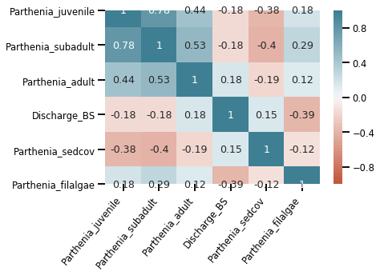

```python
#Understanding if Variables show correlation

corr = pcorr.corr()
ax = sns.heatmap(
    corr,
    vmin=-1, vmax=1, center=0,
    cmap=sns.diverging_palette(20, 220, n=100),
    annot = True
)
ax.set_xticklabels(
    ax.get_xticklabels(),
    rotation=50,
    horizontalalignment='right',
);
```

Based on the Corrplot we are able to see:

- Some positive correlation between salamander population and filamentous algae %
  - There is a stronger correlation on subadults, followed by juveniles and finally adult salamanders
  - Could presence of Algae serve as food for the growing salamanders? If so, did it impede the movement of juvenile salanaders?
- Negative correlation between sediments and salamander population.
  - Impact appears to be on juveniles and subadults more than adults
  - One can speculate if the presence of sediments caused a decline in population
- Both positive and negative correlation between water discharge and salamander population
  - Discharge appears to affect adult salanader population more than juveniles and subadults
  - While we know salamanders crave clear running fresh water, it is interesting to note some negative correlation between discharge and juveline and subadult populations

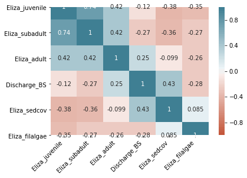

```python
corr = ecorr.corr()
ax = sns.heatmap(
    corr,
    vmin=-1, vmax=1, center=0,
    cmap=sns.diverging_palette(20, 220, n=100),
    annot = True
)
ax.set_xticklabels(
    ax.get_xticklabels(),
    rotation=45,
    horizontalalignment='right',
);
```

Just like Parthenia Springs, Eliza Springs shows much of the same correlation espcially between salamander population and discharge and sediments. However, we notice the presence of filamentous algae has negative correlation on Salamander Population in Eliza Springs. It is interesting because we had noticed the very opposite in case of Parthenia Springs. This leads us to believe that this factor may be not as significant as others.

We will shift our focus to the Impact of Sediments and Discharge on Salamander Population

```python
#Sedimentation & Its Impact on Salamander Population

#Count of population over time - 3 charts
#Count of population against sediments - 3 charts
#Count of population against discharge - 3 charts
```

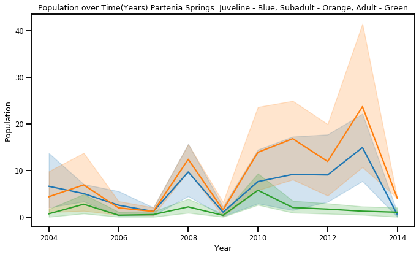

```python
#Population by Year

sns.set_context("talk",font_scale=0.7)
plt.figure(figsize=(10,6))
sns.lineplot(parthenia['Year'],parthenia.Parthenia_juvenile)
sns.lineplot(parthenia['Year'],parthenia.Parthenia_subadult)
sns.lineplot(parthenia['Year'],parthenia.Parthenia_adult)
plt.xlabel('Year')
plt.ylabel('Population')
plt.title("Population over Time(Years) Partenia Springs: Juveline - Blue, Subadult - Orange, Adult - Green")
plt.tight_layout()
```

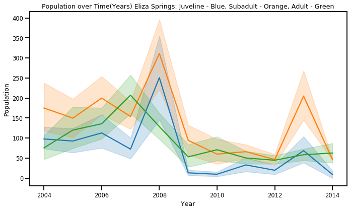

```python
sns.set_context("talk",font_scale=0.7)
plt.figure(figsize=(10,6))
sns.lineplot(eliza['Year'],eliza.Eliza_juvenile)
sns.lineplot(eliza['Year'],eliza.Eliza_subadult)
sns.lineplot(eliza['Year'],eliza.Eliza_adult)
plt.xlabel('Year')
plt.ylabel('Population')
plt.title("Population over Time(Years) Eliza Springs: Juveline - Blue, Subadult - Orange, Adult - Green")
plt.tight_layout()
```

Observations:

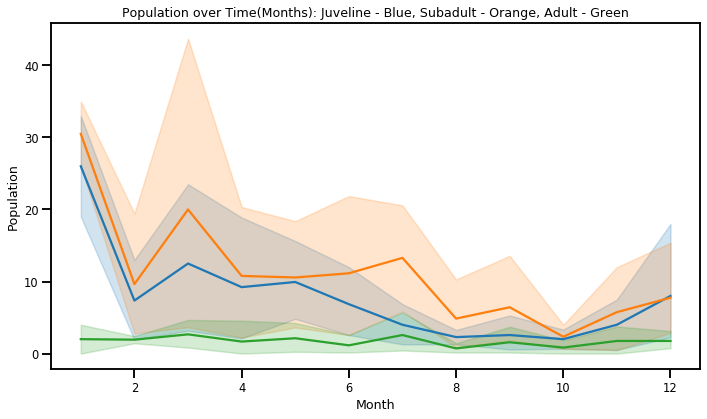

```python
#Population by Month

sns.set_context("talk",font_scale=0.7)
plt.figure(figsize=(10,6))
sns.lineplot(parthenia['Month'],parthenia.Parthenia_juvenile)
sns.lineplot(parthenia['Month'],parthenia.Parthenia_subadult)
sns.lineplot(parthenia['Month'],parthenia.Parthenia_adult)
plt.xlabel('Month')
plt.ylabel('Population')
plt.title("Population over Time(Months): Juveline - Blue, Subadult - Orange, Adult - Green")
plt.tight_layout()
```

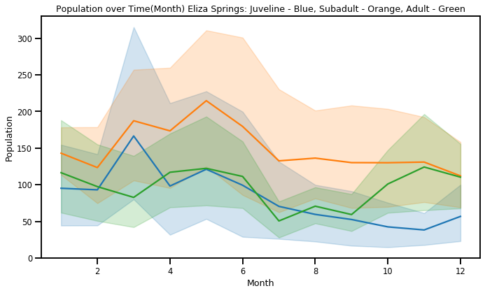

```python
sns.set_context("talk",font_scale=0.7)
plt.figure(figsize=(10,6))
sns.lineplot(eliza['Month'],eliza.Eliza_juvenile)
sns.lineplot(eliza['Month'],eliza.Eliza_subadult)
sns.lineplot(eliza['Month'],eliza.Eliza_adult)
plt.xlabel('Month')
plt.ylabel('Population')
plt.title("Population over Time(Month) Eliza Springs: Juveline - Blue, Subadult - Orange, Adult - Green")
plt.tight_layout()
```

Observations:

Parthenia Springs: Looking at population of the salamanders by month, we can see how the Juvenile population peaks in January and then tapers down around May. For the subadult population, we see tapering down in population only after August. The Adult salamander population appears to be more or less uniform throughout the year.

Eliza springs: The overall poplation of this spring is much higher than Parthenia Springs. The population trends appear to behave in a similar fashion with Eliza Springs having a peak increase in subadult salamanders in both May and March while Parthenia springs only shows this increase in March.

Eliza Springs in general showcases wider confidence bands due to added entries and more rows within this data subset.

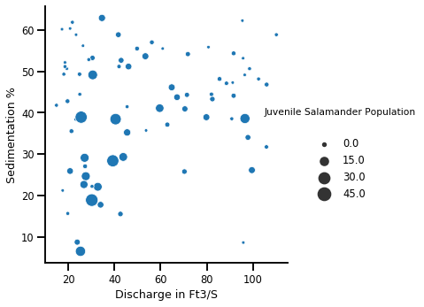

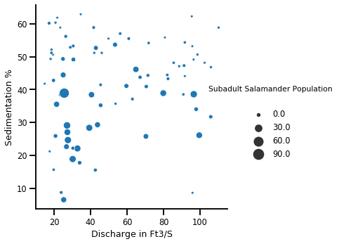

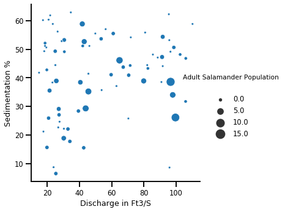

```python
a = sns.relplot(x='Discharge_BS',y='Parthenia_sedcov',size='Parthenia_juvenile', sizes = (15,200),data=parthenia)
a.set_xlabels("Discharge in Ft3/S")
a.set_ylabels("Sedimentation %")
a._legend.texts[0].set_text("")
a._legend.set_title("Juvenile Salamander Population")

b = sns.relplot(x='Discharge_BS',y='Parthenia_sedcov',size='Parthenia_subadult', sizes = (15,200),data=parthenia)
b.set_xlabels("Discharge in Ft3/S")
b.set_ylabels("Sedimentation %")
b._legend.texts[0].set_text("")
b._legend.set_title("Subadult Salamander Population")

c = sns.relplot(x='Discharge_BS',y='Parthenia_sedcov',size='Parthenia_adult', sizes = (15,200),data=parthenia)
c.set_xlabels("Discharge in Ft3/S")
c.set_ylabels("Sedimentation %")
c._legend.texts[0].set_text("")
c._legend.set_title("Adult Salamander Population")
```

Observations:

- The Juvenile Salamander population does not appear to increase with increase in discharge. They are typically observed in the 20-40 ft3 range or shallow flowing water. Furthermore, we notice that their population appears to decrease as the sedimentation levels reaches 40%.
- The subadult salamander population is onserved mostly in shallow moving waters of 20-40 ft3 but has been noticed at 80 and 100 ft3 as well. There does not appear to be an impact on their population and the discharge rate. Subadult salamanders too are mostly observed at sedmentation rates of 40% or less. They population appears to thin beyond this threshold.
- The adult salamander population unlike the juveniles and the subadults, are mostly noted in 100 ft3 of fresh flowing water. They appear to be more resilient to sedimentation and have an ability to withstand sedimentation levels of 50% and occassionally 60%.

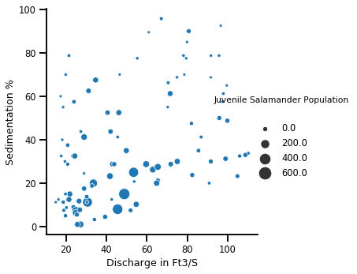

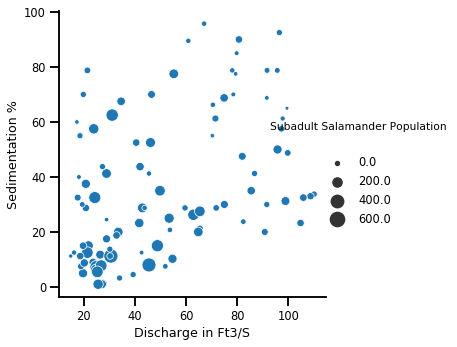

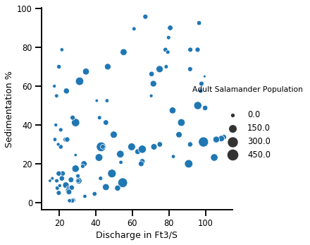

```python
a = sns.relplot(x='Discharge_BS',y='Eliza_sedcov',size='Eliza_juvenile', sizes = (15,200),data=eliza)
a.set_xlabels("Discharge in Ft3/S")
a.set_ylabels("Sedimentation %")
a._legend.texts[0].set_text("")
a._legend.set_title("Juvenile Salamander Population")

b = sns.relplot(x='Discharge_BS',y='Eliza_sedcov',size='Eliza_subadult', sizes = (15,200),data=eliza)
b.set_xlabels("Discharge in Ft3/S")
b.set_ylabels("Sedimentation %")
b._legend.texts[0].set_text("")
b._legend.set_title("Subadult Salamander Population")

c = sns.relplot(x='Discharge_BS',y='Eliza_sedcov',size='Eliza_adult', sizes = (15,200),data=eliza)
c.set_xlabels("Discharge in Ft3/S")
c.set_ylabels("Sedimentation %")
c._legend.texts[0].set_text("")
c._legend.set_title("Adult Salamander Population")
```

Observations:

In the Eliza Springs site, Juveniles appear to be surveyed in deeper waters of 50 ft3 and while are present at higher sedimentation levels, they are mostly seen in area where sedimentation levels are 30% or less.

Subadults in Eliza Springs appear to be seen mostly in the 20-50ft depth of water. Though their population appears to thin out, some subadult salamanders are noted at 100 ft3 of water as well. They appear to be more resilient to Sedimentation, being observed in waters with levels of 60%. However, upwards of 80% in terms of sedimentation levels, their population appears to thin out.

Just like in Parthenia Springs, Eliza Spring's Adult Salamanders appear prefer high dishcharge rates of 80+ ft3/s and are more resilient to sedimentation % than juveniles and subadults. While Eliza Spring Salanders are seen at sedimentation levels of 60-80% their population decreased just like subadults upwards of 80%.

### Conclusions & Future Work

Disclaimer: Data is not complete for a full year in any year- on average each year has 7-9 months worth of information. Future work will include a way to account for this and estimate this mising information.